# Анализ поиска в Яндекс Картинках: desktop vs touch

**Цель:** проверить гипотезу о различиях интересов и поведения пользователей поиска по картинкам на компьютерах и мобильных устройствах.

## Ключевые выводы

1. Данные охватывают **1–21 сентября 2021 года включительно** по московскому времени.
2. Точный запрос **«ютуб»** встречается **718 раз на desktop** и **611 раз на touch**.
3. В топе desktop преобладают **календари, справочные и учебные материалы, обои для рабочего стола**. В топе touch — **поздравления, погода, новости, музыка, фильмы и спорт**.
4. Desktop сильнее сосредоточен в дневные часы: **51,4% запросов приходится на 11:00–18:59**. Touch относительно активнее утром, ночью и поздним вечером.
5. Самые заметные контрасты: touch — поздравления, красота и мода, повседневная информация, карты метро и обои для телефона; desktop — календари и таблицы, раскраски, печать, презентации и обои для ПК.

> Тематики определены интерпретируемыми регулярными правилами. Они могут пересекаться: один запрос способен относиться к нескольким темам.

## 0. Подготовка окружения

Ноутбук ищет `data.tsv` в своей папке. Формат файла: `query<TAB>unix_timestamp<TAB>platform`.

Временные метки переводятся в `Europe/Moscow`: границы файла точно совпадают с началом и концом календарных суток по московскому времени.

```python
from pathlib import Path
import sqlite3
import warnings

import numpy as np
import pandas as pd
import matplotlib.pyplot as plt
from IPython.display import display
from sklearn.feature_extraction.text import CountVectorizer

warnings.filterwarnings('ignore', category=FutureWarning)
pd.set_option('display.max_colwidth', 120)
pd.set_option('display.float_format', lambda x: f'{x:,.3f}')
plt.rcParams['figure.figsize'] = (10, 5)
plt.rcParams['figure.dpi'] = 120

DATA_PATH = Path('data.tsv')
if not DATA_PATH.exists():
    fallback = Path('/mnt/data/data.tsv')
    if fallback.exists():
        DATA_PATH = fallback
    else:
        raise FileNotFoundError('Файл data.tsv не найден рядом с ноутбуком.')

DATA_PATH.resolve()
```

```
PosixPath('/mnt/data/yandex_images_analysis/data.tsv')
```

## 1. Загрузка и проверка качества данных

```python
df = pd.read_csv(
    DATA_PATH,
    sep='\t',
    header=None,
    names=['query', 'timestamp', 'platform'],
    dtype={'query': 'string', 'timestamp': 'int64', 'platform': 'category'},
)

df['query_norm'] = (
    df['query'].str.lower().str.strip().str.replace(r'\s+', ' ', regex=True)
)
df['datetime_utc'] = pd.to_datetime(df['timestamp'], unit='s', utc=True)
df['datetime_msk'] = df['datetime_utc'].dt.tz_convert('Europe/Moscow')
df['date_msk'] = df['datetime_msk'].dt.date
df['hour_msk'] = df['datetime_msk'].dt.hour
df['weekday_msk'] = df['datetime_msk'].dt.dayofweek

print(f"Строк: {len(df):,}".replace(',', ' '))
display(df.head())
```

```
Строк: 1 114 365
```

|  | query | timestamp | platform | query_norm | datetime_utc | datetime_msk | date_msk | hour_msk | weekday_msk |
| --- | --- | --- | --- | --- | --- | --- | --- | --- | --- |
| 0 | малевич картины | 1631806465 | desktop | малевич картины | 2021-09-16 15:34:25+00:00 | 2021-09-16 18:34:25+03:00 | 2021-09-16 | 18 | 3 |
| 1 | психология | 1631781583 | touch | психология | 2021-09-16 08:39:43+00:00 | 2021-09-16 11:39:43+03:00 | 2021-09-16 | 11 | 3 |
| 2 | с днём рождения лена | 1631771563 | touch | с днём рождения лена | 2021-09-16 05:52:43+00:00 | 2021-09-16 08:52:43+03:00 | 2021-09-16 | 8 | 3 |
| 3 | зверополис фильмы | 1631787599 | touch | зверополис фильмы | 2021-09-16 10:19:59+00:00 | 2021-09-16 13:19:59+03:00 | 2021-09-16 | 13 | 3 |
| 4 | алабай собака фото | 1631786645 | touch | алабай собака фото | 2021-09-16 10:04:05+00:00 | 2021-09-16 13:04:05+03:00 | 2021-09-16 | 13 | 3 |

```python
quality = pd.DataFrame({
    'Показатель': [
        'Количество запросов',
        'Уникальных исходных запросов',
        'Уникальных нормализованных запросов',
        'Пропусков в query',
        'Пропусков в timestamp',
        'Пропусков в platform',
        'Полных дублей строк',
    ],
    'Значение': [
        len(df),
        df['query'].nunique(),
        df['query_norm'].nunique(),
        df['query'].isna().sum(),
        df['timestamp'].isna().sum(),
        df['platform'].isna().sum(),
        df.duplicated(['query', 'timestamp', 'platform']).sum(),
    ],
})
display(quality)

platform_summary = df['platform'].value_counts().rename_axis('platform').reset_index(name='requests')
platform_summary['share_pct'] = platform_summary['requests'] / platform_summary['requests'].sum() * 100
display(platform_summary)
```

|  | Показатель | Значение |
| --- | --- | --- |
| 0 | Количество запросов | 1114365 |
| 1 | Уникальных исходных запросов | 31955 |
| 2 | Уникальных нормализованных запросов | 30033 |
| 3 | Пропусков в query | 0 |
| 4 | Пропусков в timestamp | 0 |
| 5 | Пропусков в platform | 0 |
| 6 | Полных дублей строк | 435 |

|  | platform | requests | share_pct |
| --- | --- | --- | --- |
| 0 | touch | 726101 | 65.158 |
| 1 | desktop | 388264 | 34.842 |

**Решение по дублям:** полные дубли не удаляются. Каждая строка интерпретируется как отдельный поисковый запрос; одинаковые запросы могут быть отправлены в одну секунду разными пользователями.

## 2. SQL-часть

Для демонстрации SQL используется встроенная база **SQLite**. Она поддерживает `SELECT`, агрегации, CTE и оконные функции и не требует отдельного сервера.

```python
sql_df = df[['query_norm', 'timestamp', 'platform', 'datetime_msk', 'date_msk', 'hour_msk']].copy()
sql_df['platform'] = sql_df['platform'].astype(str)
sql_df['datetime_msk'] = sql_df['datetime_msk'].astype(str)
sql_df['date_msk'] = sql_df['date_msk'].astype(str)

con = sqlite3.connect(':memory:')
sql_df.to_sql('queries', con, index=False, if_exists='replace')
con.execute('CREATE INDEX idx_queries_platform ON queries(platform)')
con.execute('CREATE INDEX idx_queries_query ON queries(query_norm)')
con.execute('CREATE INDEX idx_queries_hour ON queries(hour_msk)')
print('SQLite-таблица создана:', f"{len(sql_df):,}".replace(',', ' '), 'строк')
```

```
SQLite-таблица создана: 1 114 365 строк
```

### 2.1. Диапазон дат и объём по платформам

```python
sql_date_range = """
SELECT
    MIN(datetime_msk) AS min_datetime_msk,
    MAX(datetime_msk) AS max_datetime_msk,
    COUNT(*) AS requests,
    COUNT(DISTINCT query_norm) AS unique_queries
FROM queries;
"""
display(pd.read_sql_query(sql_date_range, con))

sql_platforms = """
SELECT
    platform,
    COUNT(*) AS requests,
    ROUND(100.0 * COUNT(*) / SUM(COUNT(*)) OVER (), 2) AS share_pct
FROM queries
GROUP BY platform
ORDER BY requests DESC;
"""
display(pd.read_sql_query(sql_platforms, con))
```

|  | min_datetime_msk | max_datetime_msk | requests | unique_queries |
| --- | --- | --- | --- | --- |
| 0 | 2021-09-01 00:00:00+03:00 | 2021-09-21 23:59:59+03:00 | 1114365 | 30033 |

|  | platform | requests | share_pct |
| --- | --- | --- | --- |
| 0 | touch | 726101 | 65.160 |
| 1 | desktop | 388264 | 34.840 |

### 2.2. Запрос «ютуб»

```python
sql_youtube = """
SELECT platform, COUNT(*) AS requests
FROM queries
WHERE query_norm = 'ютуб'
GROUP BY platform
ORDER BY platform;
"""
youtube_exact_sql = pd.read_sql_query(sql_youtube, con)
display(youtube_exact_sql)
```

|  | platform | requests |
| --- | --- | --- |
| 0 | desktop | 718 |
| 1 | touch | 611 |

### 2.3. Топ-10 запросов на каждой платформе

```python
sql_top10 = """
WITH query_frequency AS (
    SELECT platform, query_norm, COUNT(*) AS requests
    FROM queries
    GROUP BY platform, query_norm
),
ranked AS (
    SELECT
        platform,
        query_norm,
        requests,
        ROW_NUMBER() OVER (
            PARTITION BY platform
            ORDER BY requests DESC, query_norm
        ) AS rn
    FROM query_frequency
)
SELECT platform, rn AS rank, query_norm, requests
FROM ranked
WHERE rn <= 10
ORDER BY platform, rank;
"""
top10_sql = pd.read_sql_query(sql_top10, con)
display(top10_sql)
```

|  | platform | rank | query_norm | requests |
| --- | --- | --- | --- | --- |
| 0 | desktop | 1 | календарь 2021 | 2810 |
| 1 | desktop | 2 | таблица менделеева | 2659 |
| 2 | desktop | 3 | картинки | 1720 |
| 3 | desktop | 4 | английский алфавит | 1352 |
| 4 | desktop | 5 | обои на рабочий стол | 1143 |
| 5 | desktop | 6 | одноклассники (социальная сеть) | 1116 |
| 6 | desktop | 7 | алфавит | 923 |
| 7 | desktop | 8 | таблица квадратов | 883 |
| 8 | desktop | 9 | таблица умножения | 872 |
| 9 | desktop | 10 | youtube | 838 |
| 10 | touch | 1 | с днём рождения женщине | 4924 |
| 11 | touch | 2 | с днём рождения | 4123 |
| 12 | touch | 3 | с днём рождения мужчине | 3669 |
| 13 | touch | 4 | с днем рождения | 3315 |
| 14 | touch | 5 | погода | 2918 |
| 15 | touch | 6 | игры | 2873 |
| 16 | touch | 7 | фильмы | 2770 |
| 17 | touch | 8 | новости | 2733 |
| 18 | touch | 9 | музыка | 2723 |
| 19 | touch | 10 | спорт | 2662 |

## 3. Ответ 1 — диапазон дат

```python
date_answer = pd.DataFrame({
    'timezone': ['Europe/Moscow', 'UTC'],
    'from': [df['datetime_msk'].min(), df['datetime_utc'].min()],
    'to': [df['datetime_msk'].max(), df['datetime_utc'].max()],
})
display(date_answer)
```

|  | timezone | from | to |
| --- | --- | --- | --- |
| 0 | Europe/Moscow | 2021-09-01 00:00:00+03:00 | 2021-09-21 23:59:59+03:00 |
| 1 | UTC | 2021-08-31 21:00:00+00:00 | 2021-09-21 20:59:59+00:00 |

**Ответ:** по московскому времени выборка охватывает период **с 1 сентября 2021 года 00:00:00 по 21 сентября 2021 года 23:59:59**, то есть 21 полный календарный день.

## 4. Ответ 2 — количество запросов с текстом «ютуб»

```python
platform_totals = df['platform'].value_counts()

youtube_exact = (
    df.loc[df['query_norm'].eq('ютуб')]
    .groupby('platform', observed=True).size()
    .reindex(['desktop', 'touch'], fill_value=0)
    .rename('exact_requests').reset_index()
)
youtube_exact['platform_requests'] = youtube_exact['platform'].astype(str).map(platform_totals)
youtube_exact['share_pct'] = youtube_exact['exact_requests'] / youtube_exact['platform_requests'] * 100

youtube_contains = (
    df.loc[df['query_norm'].str.contains('ютуб', regex=False, na=False)]
    .groupby('platform', observed=True).size()
    .reindex(['desktop', 'touch'], fill_value=0)
    .rename('contains_requests').reset_index()
)
youtube_result = youtube_exact.merge(youtube_contains, on='platform')
display(youtube_result)
```

|  | platform | exact_requests | platform_requests | share_pct | contains_requests |
| --- | --- | --- | --- | --- | --- |
| 0 | desktop | 718 | 388264 | 0.185 | 806 |
| 1 | touch | 611 | 726101 | 0.084 | 732 |

Основная трактовка — **точное совпадение нормализованного запроса** с «ютуб»:

- desktop — **718**;
- touch — **611**.

Для контроля посчитано вхождение подстроки «ютуб»: desktop — **806**, touch — **732**.

## 5. Ответ 3 — топ-10 запросов

```python
top10 = df.groupby(['platform', 'query_norm'], observed=True).size().rename('requests').reset_index()
top10['share_pct'] = top10['requests'] / top10['platform'].astype(str).map(platform_totals) * 100
top10 = (
    top10.sort_values(['platform', 'requests', 'query_norm'], ascending=[True, False, True])
    .groupby('platform', observed=True).head(10).copy()
)
top10['rank'] = top10.groupby('platform', observed=True).cumcount() + 1
top10 = top10[['platform', 'rank', 'query_norm', 'requests', 'share_pct']]
display(top10)
```

|  | platform | rank | query_norm | requests | share_pct |
| --- | --- | --- | --- | --- | --- |
| 7947 | desktop | 1 | календарь 2021 | 2810 | 0.724 |
| 19738 | desktop | 2 | таблица менделеева | 2659 | 0.685 |
| 8324 | desktop | 3 | картинки | 1720 | 0.443 |
| 2125 | desktop | 4 | английский алфавит | 1352 | 0.348 |
| 13053 | desktop | 5 | обои на рабочий стол | 1143 | 0.294 |
| 13341 | desktop | 6 | одноклассники (социальная сеть) | 1116 | 0.287 |
| 1981 | desktop | 7 | алфавит | 923 | 0.238 |
| 19730 | desktop | 8 | таблица квадратов | 883 | 0.227 |
| 19778 | desktop | 9 | таблица умножения | 872 | 0.225 |
| 1520 | desktop | 10 | youtube | 838 | 0.216 |
| 45677 | touch | 1 | с днём рождения женщине | 4924 | 0.678 |
| 45611 | touch | 2 | с днём рождения | 4123 | 0.568 |
| 45762 | touch | 3 | с днём рождения мужчине | 3669 | 0.505 |
| 45461 | touch | 4 | с днем рождения | 3315 | 0.457 |
| 41904 | touch | 5 | погода | 2918 | 0.402 |
| 31914 | touch | 6 | игры | 2873 | 0.396 |
| 49931 | touch | 7 | фильмы | 2770 | 0.381 |
| 39444 | touch | 8 | новости | 2733 | 0.376 |
| 38155 | touch | 9 | музыка | 2723 | 0.375 |
| 47448 | touch | 10 | спорт | 2662 | 0.367 |

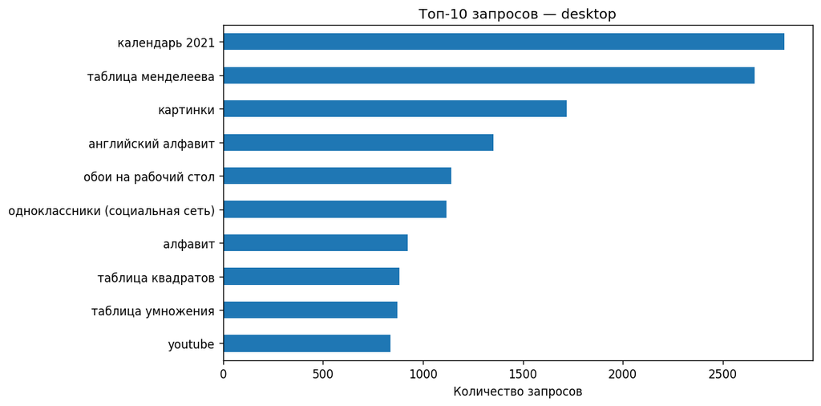

```python
desktop_top = top10[top10['platform'] == 'desktop'].sort_values('requests')
ax = desktop_top.plot.barh(x='query_norm', y='requests', legend=False, title='Топ-10 запросов — desktop')
ax.set_xlabel('Количество запросов')
ax.set_ylabel('')
plt.tight_layout()
plt.show()
```

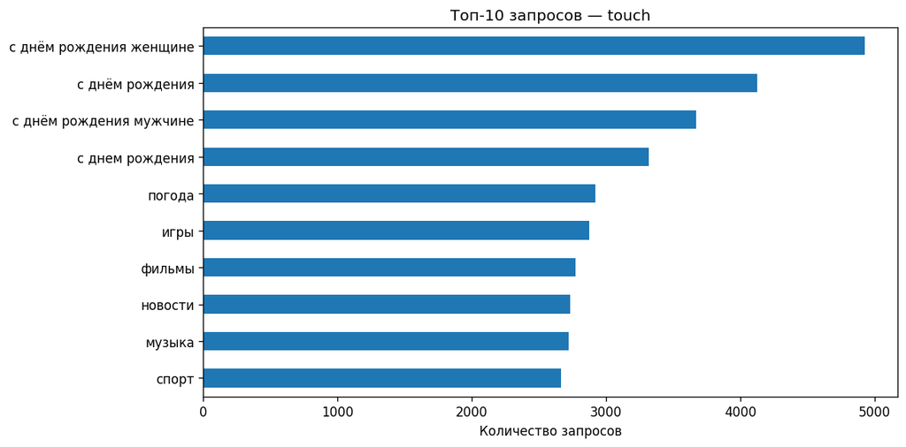

```python
touch_top = top10[top10['platform'] == 'touch'].sort_values('requests')
ax = touch_top.plot.barh(x='query_norm', y='requests', legend=False, title='Топ-10 запросов — touch')
ax.set_xlabel('Количество запросов')
ax.set_ylabel('')
plt.tight_layout()
plt.show()
```

### Интерпретация

**Desktop:** утилитарные и справочные сценарии — календарь, таблица Менделеева, алфавит, таблицы квадратов и умножения; выражена привязка к устройству — «обои на рабочий стол»; присутствуют навигационные запросы к сайтам и сервисам.

Сравнивать только абсолютные частоты нельзя: touch содержит 65,2% всех строк. Поэтому далее используются доли внутри каждой платформы.

## 6. Ответ 4 — суточный профиль трафика

```python
hourly = df.groupby(['platform', 'hour_msk'], observed=True).size().rename('requests').reset_index()
hourly['share_pct'] = hourly['requests'] / hourly['platform'].astype(str).map(platform_totals) * 100
hourly_pivot = hourly.pivot(index='hour_msk', columns='platform', values='share_pct')
display(hourly_pivot.round(3))
```

| platform hour_msk | desktop | touch |
| --- | --- | --- |
| 0 | 1.605 | 2.015 |
| 1 | 0.930 | 1.241 |
| 2 | 0.638 | 0.951 |
| 3 | 0.575 | 0.961 |
| 4 | 0.722 | 1.223 |
| 5 | 1.027 | 1.700 |
| 6 | 1.577 | 2.764 |
| 7 | 2.415 | 4.003 |
| 8 | 3.588 | 5.594 |
| 9 | 4.763 | 5.941 |
| 10 | 5.325 | 5.953 |
| 11 | 5.697 | 5.117 |
| 12 | 6.001 | 5.124 |
| 13 | 6.240 | 5.037 |
| 14 | 6.561 | 5.111 |
| 15 | 6.788 | 5.125 |
| 16 | 6.957 | 5.236 |
| 17 | 6.661 | 5.304 |
| 18 | 6.529 | 5.439 |
| 19 | 6.581 | 5.597 |
| 20 | 6.396 | 6.346 |
| 21 | 5.561 | 6.041 |
| 22 | 4.152 | 5.017 |
| 23 | 2.709 | 3.158 |

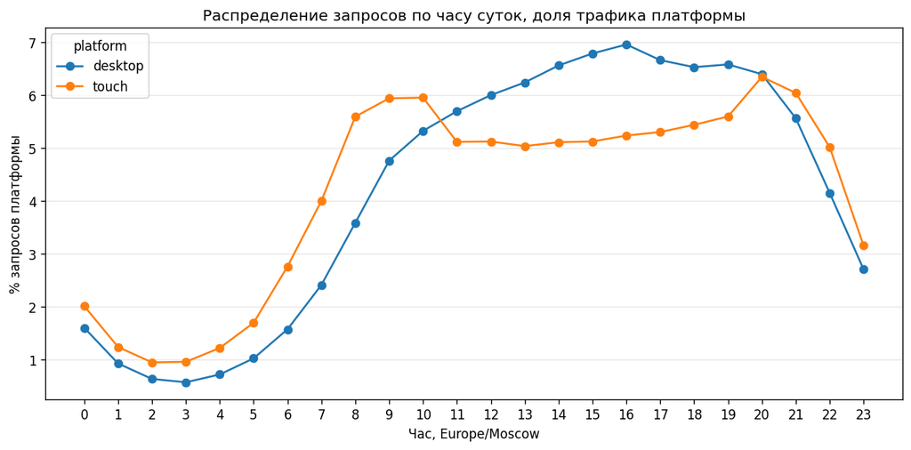

```python
ax = hourly_pivot.plot(marker='o', title='Распределение запросов по часу суток, доля трафика платформы')
ax.set_xlabel('Час, Europe/Moscow')
ax.set_ylabel('% запросов платформы')
ax.set_xticks(range(24))
ax.grid(axis='y', alpha=0.3)
plt.tight_layout()
plt.show()
```

```python
def day_period(hour):
    if 0 <= hour <= 5:
        return 'Ночь 00–05'
    if 6 <= hour <= 10:
        return 'Утро 06–10'
    if 11 <= hour <= 18:
        return 'День 11–18'
    return 'Вечер 19–23'

period_order = ['Ночь 00–05', 'Утро 06–10', 'День 11–18', 'Вечер 19–23']
period_df = df[['platform', 'hour_msk']].copy()
period_df['day_period'] = period_df['hour_msk'].map(day_period)
period_summary = period_df.groupby(['platform', 'day_period'], observed=True).size().rename('requests').reset_index()
period_summary['share_pct'] = period_summary['requests'] / period_summary['platform'].astype(str).map(platform_totals) * 100
period_pivot = period_summary.pivot(index='day_period', columns='platform', values='share_pct').reindex(period_order)
display(period_pivot.round(2))
```

| platform day_period | desktop | touch |
| --- | --- | --- |
| Ночь 00–05 | 5.500 | 8.090 |
| Утро 06–10 | 17.670 | 24.250 |
| День 11–18 | 51.430 | 41.490 |
| Вечер 19–23 | 25.400 | 26.160 |

```python
peak_hours = (
    hourly.sort_values(['platform', 'share_pct'], ascending=[True, False])
    .groupby('platform', observed=True).head(3)
    .sort_values(['platform', 'share_pct'], ascending=[True, False])
)
display(peak_hours)
```

|  | platform | hour_msk | requests | share_pct |
| --- | --- | --- | --- | --- |
| 16 | desktop | 16 | 27013 | 6.957 |
| 15 | desktop | 15 | 26354 | 6.788 |
| 17 | desktop | 17 | 25864 | 6.661 |
| 44 | touch | 20 | 46080 | 6.346 |
| 45 | touch | 21 | 43867 | 6.041 |
| 34 | touch | 10 | 43224 | 5.953 |

### Как объяснить различия

- **Desktop** достигает максимума днём и сильнее связан с рабочим или учебным местом.
- **Touch** быстрее растёт утром, остаётся относительно активнее ночью и снова усиливается вечером: телефон доступен после пробуждения, в дороге, во время перерывов и перед сном.
- У touch распределение более растянуто по суткам, а desktop концентрируется в рабочем интервале.

Это поведенческая интерпретация, а не доказанная причинность: в данных нет пользователей, географии, сессий и контекста использования.

## 7. Ответ 5 — контрастные тематики

Используется **интерпретируемая multi-label классификация** по регулярным выражениям. Один запрос может попадать в несколько тем. Доля темы — доля запросов платформы, содержащих её маркеры. Контраст измеряется разностью долей в процентных пунктах и отношением долей touch/desktop.

```python
topic_patterns = {
    'Поздравления и пожелания': r'д[её]н[ья]\s+рожд|поздрав|открытк|доброе\s+утро|добрым\s+утром|с\s+добрым|пожелан|с\s+1\s+сентябр|день\s+знаний|дн[её]м\s+ангела|рождеств|праздник',
    'Календари, таблицы и алфавиты': r'календар|таблица\s+(?:менделеева|умножения|квадрат)|алфавит|формулы?\s+сокращ',
    'Раскраски': r'раскраск',
    'Печать и шаблоны': r'распечатать|шаблон|трафарет',
    'Презентации и рабочие материалы': r'презентац|спасибо\s+за\s+внимание|iso\s*9001|бланк|договор|портал\s+государственных',
    'Обои и фоны для ПК': r'рабочи[йего]+\s+стол|обои\s+(?:на|для)\s+(?:пк|компьютер)|background',
    'Обои и фоны для телефона': r'обои\s+(?:на|для)\s+(?:телефон|айфон|iphone|android|андроид)|заставк[аи]\s+(?:на|для)\s+(?:телефон|айфон|iphone|android|андроид)',
    'Новости, погода и спорт': r'\bновост|\bпогод|\bспорт\b|футбол|хоккей',
    'Карты и городской транспорт': r'метро|схема\s+проезда|карта\s+(?:москв|санкт|петербург|спб|города)|маршрут',
    'Красота и мода': r'\bмод[аы]\b|маникюр|ногт|причес|стриж|макияж|космет|тату|френч|дизайн\s+ногт',
    'Кулинария и еда': r'кулинар|рецепт|как\s+(?:варить|приготовить|готовить)|еда|торт|салат|блюд|гречк',
    'Развлечения и медиа': r'\bигр[аы]\b|фильм|кино|музык|песн|аниме|сериал|мульт|youtube|ютуб|minecraft|майнкрафт',
    'Соцсети и мессенджеры': r'одноклассники|социальн\w*\s+сет|вконтакте|\bвк\b|whatsapp|ватсап|telegram|телеграм|instagram|инстаграм',
    'Контент 18+': r'\bbokep\b|\bbokeb\b|\bmemek\b|\bkontol\b|\bngentot\b|\bxxx\b|\bххх\b|\bxxnx\b|\bporn|\bпорно\b|\bminus8\b|\bcolmek\b',
    'Путешествия': r'путешеств|туризм|достопримеч|отел|курорт|пляж',
}
```

```python
topic_rows = []
for topic, pattern in topic_patterns.items():
    mask = df['query_norm'].str.contains(pattern, regex=True, na=False)
    counts = df.loc[mask].groupby('platform', observed=True).size().reindex(['desktop', 'touch'], fill_value=0)
    desktop_count = int(counts['desktop'])
    touch_count = int(counts['touch'])
    desktop_share = desktop_count / platform_totals['desktop'] * 100
    touch_share = touch_count / platform_totals['touch'] * 100
    topic_rows.append({
        'topic': topic,
        'desktop_count': desktop_count,
        'touch_count': touch_count,
        'desktop_share_pct': desktop_share,
        'touch_share_pct': touch_share,
        'diff_pp_touch_minus_desktop': touch_share - desktop_share,
        'touch_to_desktop_ratio': (touch_share + 1e-9) / (desktop_share + 1e-9),
    })

topic_contrast = pd.DataFrame(topic_rows).sort_values('diff_pp_touch_minus_desktop', ascending=False)
display(topic_contrast.round(3))
```

|  | topic | desktop_count | touch_count | desktop_share_pct | touch_share_pct | diff_pp_touch_minus_desktop | touch_to_desktop_ratio |
| --- | --- | --- | --- | --- | --- | --- | --- |
| 0 | Поздравления и пожелания | 8164 | 56776 | 2.103 | 7.819 | 5.717 | 3.719 |
| 9 | Красота и мода | 3694 | 21581 | 0.951 | 2.972 | 2.021 | 3.124 |
| 7 | Новости, погода и спорт | 3045 | 15833 | 0.784 | 2.181 | 1.396 | 2.780 |
| 13 | Контент 18+ | 234 | 7636 | 0.060 | 1.052 | 0.991 | 17.449 |
| 8 | Карты и городской транспорт | 3055 | 11063 | 0.787 | 1.524 | 0.737 | 1.936 |
| 11 | Развлечения и медиа | 12183 | 28032 | 3.138 | 3.861 | 0.723 | 1.230 |
| 10 | Кулинария и еда | 1625 | 7261 | 0.419 | 1.000 | 0.581 | 2.389 |
| 6 | Обои и фоны для телефона | 204 | 4507 | 0.053 | 0.621 | 0.568 | 11.814 |
| 14 | Путешествия | 1327 | 5331 | 0.342 | 0.734 | 0.392 | 2.148 |
| 12 | Соцсети и мессенджеры | 3403 | 1695 | 0.876 | 0.233 | -0.643 | 0.266 |
| 4 | Презентации и рабочие материалы | 3062 | 422 | 0.789 | 0.058 | -0.731 | 0.074 |
| 3 | Печать и шаблоны | 3256 | 297 | 0.839 | 0.041 | -0.798 | 0.049 |
| 5 | Обои и фоны для ПК | 5529 | 428 | 1.424 | 0.059 | -1.365 | 0.041 |
| 2 | Раскраски | 8899 | 706 | 2.292 | 0.097 | -2.195 | 0.042 |
| 1 | Календари, таблицы и алфавиты | 21680 | 18057 | 5.584 | 2.487 | -3.097 | 0.445 |

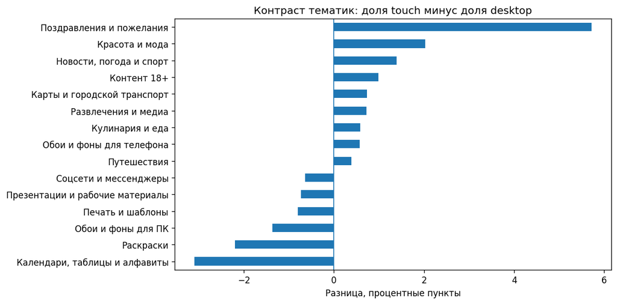

```python
plot_data = topic_contrast.sort_values('diff_pp_touch_minus_desktop')
ax = plot_data.plot.barh(x='topic', y='diff_pp_touch_minus_desktop', legend=False, title='Контраст тематик: доля touch минус доля desktop')
ax.axvline(0, linewidth=1)
ax.set_xlabel('Разница, процентные пункты')
ax.set_ylabel('')
plt.tight_layout()
plt.show()
```

### Основные контрасты

**Сильнее на touch**

- поздравления и пожелания: **7,82% против 2,10%**, в **3,7 раза** выше;
- красота и мода: **2,97% против 0,95%**, в **3,1 раза**;
- новости, погода и спорт: **2,18% против 0,78%**, в **2,8 раза**;
- обои для телефона: **0,62% против 0,05%**, почти в **11,8 раза**;
- карты и городской транспорт: **1,52% против 0,79%**, почти в **1,9 раза**.

**Сильнее на desktop**

- календари, таблицы и алфавиты: **5,58% против 2,49%**;
- раскраски: **2,29% против 0,10%**, примерно в **23,6 раза** выше на desktop;
- обои и фоны для ПК: **1,42% против 0,06%**, примерно в **24 раза**;
- печать и шаблоны: **0,84% против 0,04%**, примерно в **20 раз**;
- презентации и рабочие материалы: **0,79% против 0,06%**, примерно в **13,6 раза**;
- соцсети и мессенджеры: **0,88% против 0,23%**, примерно в **3,8 раза**.

## 8. Data-driven проверка тематических выводов

Для независимой проверки словарного подхода сравниваются слова и биграммы по относительной частоте. Положительный `log2_touch_desktop` означает перевес touch, отрицательный — desktop.

```python
query_platform = df.groupby(['query_norm', 'platform'], observed=True).size().unstack(fill_value=0)

russian_stopwords = [
    'и', 'в', 'во', 'на', 'с', 'со', 'к', 'ко', 'по', 'из', 'за', 'для', 'от', 'до', 'у', 'о', 'об', 'про',
    'а', 'но', 'или', 'как', 'что', 'это', 'этот', 'эта', 'эти', 'не', 'без', 'при', 'под', 'над',
    'фото', 'фотографии', 'картинка', 'картинки', 'изображение', 'изображения', 'скачать', 'бесплатно',
    'смотреть', 'онлайн', 'год', 'года', '2021', '2022', 'текст', 'видео', 'новые', 'новый',
    'красивая', 'красивые', 'красивый', 'большие', 'лучшие',
]

vectorizer = CountVectorizer(
    lowercase=False,
    token_pattern=r'(?u)\b[а-яёa-z0-9]{2,}\b',
    ngram_range=(1, 2),
    binary=True,
    stop_words=russian_stopwords,
    min_df=2,
)
X = vectorizer.fit_transform(query_platform.index)
terms = np.array(vectorizer.get_feature_names_out())
desktop_term_requests = np.asarray(X.T.dot(query_platform['desktop'].to_numpy())).ravel()
touch_term_requests = np.asarray(X.T.dot(query_platform['touch'].to_numpy())).ravel()

term_contrast = pd.DataFrame({'term': terms, 'desktop_count': desktop_term_requests, 'touch_count': touch_term_requests})
term_contrast['desktop_share'] = term_contrast['desktop_count'] / platform_totals['desktop']
term_contrast['touch_share'] = term_contrast['touch_count'] / platform_totals['touch']
term_contrast['total_count'] = term_contrast['desktop_count'] + term_contrast['touch_count']
epsilon = 1e-5
term_contrast['log2_touch_desktop'] = np.log2((term_contrast['touch_share'] + epsilon) / (term_contrast['desktop_share'] + epsilon))
term_contrast = term_contrast[term_contrast['total_count'] >= 300]
```

```python
explicit_markers = {
    'bokep', 'bokeb', 'memek', 'kontol', 'ngentot', 'xxx', 'ххх', 'xxnx',
    'porn', 'порно', 'minus8', 'colmek', 'indo', 'jepang', 'ankha minus8',
}
term_contrast_public = term_contrast[~term_contrast['term'].isin(explicit_markers)]

touch_terms = term_contrast_public.nlargest(15, 'log2_touch_desktop')[['term', 'desktop_count', 'touch_count', 'log2_touch_desktop']]
desktop_terms = term_contrast_public.nsmallest(15, 'log2_touch_desktop')[['term', 'desktop_count', 'touch_count', 'log2_touch_desktop']]

print('Маркеры touch')
display(touch_terms.round(3))
print('Маркеры desktop')
display(desktop_terms.round(3))
```

```
Маркеры touch
```

|  | term | desktop_count | touch_count | log2_touch_desktop |
| --- | --- | --- | --- | --- |
| 1383 | варить гречку | 6 | 319 | 4.142 |
| 1997 | гречку | 6 | 319 | 4.142 |
| 8315 | телефон высокого | 8 | 363 | 4.058 |
| 5584 | осенним | 25 | 816 | 3.930 |
| 5585 | осенним утром | 23 | 733 | 3.880 |
| 2420 | добрым осенним | 24 | 724 | 3.810 |
| 1278 | брату | 8 | 302 | 3.799 |
| 7066 | рождения брату | 8 | 302 | 3.799 |
| 3233 | казино | 73 | 1981 | 3.790 |
| 7137 | рождения сына | 33 | 915 | 3.741 |
| 5545 | оригинальные | 19 | 539 | 3.674 |
| 2407 | доброе осеннее | 33 | 862 | 3.656 |
| 2682 | женщине оригинальные | 10 | 311 | 3.616 |
| 845 | анимация | 12 | 354 | 3.604 |
| 8724 | утром осенние | 18 | 489 | 3.600 |

```
Маркеры desktop
```

|  | term | desktop_count | touch_count | log2_touch_desktop |
| --- | --- | --- | --- | --- |
| 1951 | государственных | 480 | 2 | -6.610 |
| 1952 | государственных услуг | 480 | 2 | -6.610 |
| 6299 | портал государственных | 480 | 2 | -6.610 |
| 8686 | услуг | 480 | 2 | -6.610 |
| 8687 | услуг российской | 480 | 2 | -6.610 |
| 7860 | социальная сеть | 1158 | 20 | -6.317 |
| 8740 | учебный учителя | 612 | 8 | -6.238 |
| 5436 | одноклассники социальная | 1158 | 25 | -6.074 |
| 8739 | учебный | 724 | 15 | -5.934 |
| 136 | auto | 356 | 4 | -5.901 |
| 531 | theft | 356 | 4 | -5.901 |
| 532 | theft auto | 356 | 4 | -5.901 |
| 260 | grand | 339 | 4 | -5.831 |
| 261 | grand theft | 339 | 4 | -5.831 |
| 3274 | календарь учителя | 390 | 7 | -5.691 |

## 9. Выгрузки для DataLens

```python
EXPORT_DIR = Path('exports')
EXPORT_DIR.mkdir(exist_ok=True)
platform_summary.to_csv(EXPORT_DIR / 'platform_summary.csv', index=False, encoding='utf-8-sig')
top10.to_csv(EXPORT_DIR / 'top10_queries.csv', index=False, encoding='utf-8-sig')
hourly.to_csv(EXPORT_DIR / 'hourly_traffic.csv', index=False, encoding='utf-8-sig')
period_summary.to_csv(EXPORT_DIR / 'day_period_traffic.csv', index=False, encoding='utf-8-sig')
topic_contrast.to_csv(EXPORT_DIR / 'topic_contrast.csv', index=False, encoding='utf-8-sig')
print('Созданы файлы:')
for file in sorted(EXPORT_DIR.glob('*.csv')):
    print('-', file)
```

```
Созданы файлы:
- exports/day_period_traffic.csv
- exports/hourly_traffic.csv
- exports/platform_summary.csv
- exports/top10_queries.csv
- exports/topic_contrast.csv
```

### Предлагаемая структура дашборда DataLens

1. Селектор платформы — `platform`.
2. Индикаторы — число запросов, доля платформы, число уникальных запросов.
3. Линейный график — `hour_msk` по X, `share_pct` по Y, серия `platform`.
4. Горизонтальный бар-чарт — топ запросов по `requests`.
5. Diverging bar chart — `topic` и `diff_pp_touch_minus_desktop`.
6. Таблица тематик — доли, абсолютные значения и отношение touch/desktop.

## 10. Ограничения анализа

1. Это семпл, а не полный трафик; механизм семплирования неизвестен.
2. Нет `user_id` и `session_id`, поэтому анализируются запросы, а не пользователи и сессии.
3. Нет географии, возраста, источника перехода и характеристик устройства.
4. Нельзя отличить навигационный запрос от реального поиска изображения.
5. Тематическая классификация словарная и multi-label; её стоит валидировать на размеченной выборке.
6. Данные относятся к сентябрю 2021 года, поэтому часть всплесков может быть сезонной.
7. При таком объёме почти любые отличия статистически значимы; важнее практический размер эффекта.

## 11. Краткий рассказ для интервью

> Я начал с проверки структуры данных и временной зоны. Выборка содержит 1,11 млн запросов за 21 полный день — с 1 по 21 сентября 2021 года по Москве. Поскольку touch занимает около 65% строк, платформы я сравнивал по долям, а не только по абсолютным значениям.

> Гипотеза о различии интересов подтверждается. На desktop сильнее учебно-рабочие сценарии: календари, таблицы, презентации, печать, раскраски и обои для рабочего стола. На touch сильнее поздравления, повседневная информация, красота, карты метро и контент для телефона.

> Поведение в течение суток также различается. Desktop концентрируется в рабочие часы: более половины трафика приходится на 11–18 часов. Touch относительно активнее утром, вечером и ночью, что соответствует постоянной доступности смартфона.

> Темы я выделил прозрачными регулярными правилами и дополнительно проверил результат data-driven анализом слов и биграмм. Следующим шагом я бы провёл ручную разметку стратифицированной выборки, оценил качество тематизации и построил устойчивый классификатор.

## 12. Идеи продуктовых действий

- Для touch: быстрее показывать открытки и изображения для пересылки, учитывать мобильное разрешение, усиливать локальные и картографические сценарии.
- Для desktop: поддерживать скачивание в высоком разрешении, печать, копирование в презентации и фильтры по формату/ориентации.
- Персонализировать быстрые фильтры по платформе и проверять эффект A/B-тестом.
- Для сезонных тем заранее готовить коллекции и подсказки.
- Отдельно исследовать навигационные запросы к сайтам и сервисам.